# R Notebook

```r
library(tidyverse)
library(janitor)
library(GGally)
library(modelr)
library(ggfortify)
library(lubridate)
library(broom)
```

```r
avocados <- read_csv("data/avocado.csv") %>%
  clean_names()
glimpse(avocados)
```

```
Rows: 18,249
Columns: 14
$ x1            <dbl> 0, 1, 2, 3, 4, 5, 6, 7, 8, 9, 10, 11, 12, 13, 14, 15, 16, 17, 18, 19, 20, 21, 22, 23, 24, 25, 26, 27, 28, 29, 30, 31, 32, 33, 34, 35, 36, 3…
$ date          <date> 2015-12-27, 2015-12-20, 2015-12-13, 2015-12-06, 2015-11-29, 2015-11-22, 2015-11-15, 2015-11-08, 2015-11-01, 2015-10-25, 2015-10-18, 2015-1…
$ average_price <dbl> 1.33, 1.35, 0.93, 1.08, 1.28, 1.26, 0.99, 0.98, 1.02, 1.07, 1.12, 1.28, 1.31, 0.99, 1.33, 1.28, 1.11, 1.07, 1.34, 1.33, 1.12, 1.45, 1.11, 1…
$ total_volume  <dbl> 64236.62, 54876.98, 118220.22, 78992.15, 51039.60, 55979.78, 83453.76, 109428.33, 99811.42, 74338.76, 84843.44, 64489.17, 61007.10, 106803.…
$ x4046         <dbl> 1036.74, 674.28, 794.70, 1132.00, 941.48, 1184.27, 1368.92, 703.75, 1022.15, 842.40, 924.86, 1582.03, 2268.32, 1204.88, 1028.03, 985.73, 87…
$ x4225         <dbl> 54454.85, 44638.81, 109149.67, 71976.41, 43838.39, 48067.99, 73672.72, 101815.36, 87315.57, 64757.44, 75595.85, 52677.92, 49880.67, 99409.2…
$ x4770         <dbl> 48.16, 58.33, 130.50, 72.58, 75.78, 43.61, 93.26, 80.00, 85.34, 113.00, 117.07, 105.32, 101.36, 154.84, 150.50, 142.00, 240.79, 335.43, 444…
$ total_bags    <dbl> 8696.87, 9505.56, 8145.35, 5811.16, 6183.95, 6683.91, 8318.86, 6829.22, 11388.36, 8625.92, 8205.66, 10123.90, 8756.75, 6034.46, 9267.36, 92…
$ small_bags    <dbl> 8603.62, 9408.07, 8042.21, 5677.40, 5986.26, 6556.47, 8196.81, 6266.85, 11104.53, 8061.47, 7877.86, 9866.27, 8379.98, 5888.87, 8489.10, 866…
$ large_bags    <dbl> 93.25, 97.49, 103.14, 133.76, 197.69, 127.44, 122.05, 562.37, 283.83, 564.45, 327.80, 257.63, 376.77, 145.59, 778.26, 621.49, 227.23, 87.80…
$ x_large_bags  <dbl> 0.00, 0.00, 0.00, 0.00, 0.00, 0.00, 0.00, 0.00, 0.00, 0.00, 0.00, 0.00, 0.00, 0.00, 0.00, 0.00, 0.00, 0.00, 0.00, 0.00, 0.00, 0.00, 0.00, 0…
$ type          <chr> "conventional", "conventional", "conventional", "conventional", "conventional", "conventional", "conventional", "conventional", "convention…
$ year          <dbl> 2015, 2015, 2015, 2015, 2015, 2015, 2015, 2015, 2015, 2015, 2015, 2015, 2015, 2015, 2015, 2015, 2015, 2015, 2015, 2015, 2015, 2015, 2015, 2…
$ region        <chr> "Albany", "Albany", "Albany", "Albany", "Albany", "Albany", "Albany", "Albany", "Albany", "Albany", "Albany", "Albany", "Albany", "Albany",…
```

```r
min(avocados$date)
```

```
[1] "2015-01-04"
```

```r
max(avocados$date)
```

```
[1] "2018-03-25"
```

X1 is a row number so we will drop that Date - the date range is from Jan 2015 - March 2018, we could split this up into year and quarter. By spitting into quarter we create less dummy variables instead of month There is already a year column so lets create a quarter, we also need to make sure that they are treadt as factors

```r
clean_avocados <- avocados %>%
  dplyr::select(-x1) %>%
  mutate(quarter = factor(quarter(date)), .after = date) %>%
  mutate(year = factor(year), .after = quarter)
```

```r
avocados %>%
  distinct(region) %>%
  mutate(regions = case_when(
    str_detect(region, "Al|Bal|Bos|Buff|Harris|Hart|York|Engl|Phil|Pitts|Sy|North" ) ~ "north_east",
    str_detect(region, "At|Char|Dal|Hous|Jacks|Louis|Miami|Nash|Orlea|Orl|Pheo|Ral|Rich|Roa|Caro|Tamp|Mid|South") ~ "south",
    str_detect(region, "Boi|Ch|Cin|Col|Det|Grand|Great|India|St" ) ~ "mid_west",
    str_detect(region, "Cal|Den|Las|Los|Plain|Port|Sac|San|Spo|Sea|Phoe|Tex|West" ) ~ "west",
    TRUE ~ "group_region"

  )) %>%
  filter(regions == "group_region")
```

| region | regions |
| --- | --- |
| TotalUS | group_region |

Looking at the regions there appears to be both cities and regions, since we are tyring to predict the average price of the avocado I have groupped them into the smaller regions but I have added a flag column so I coan filter them in and out if they have an impact on the pirce.

```r
clean_avocados <- clean_avocados %>%
  mutate(grouped_market = region %in% c("California", "West", "SouthCentral", "GreatLakes",
                                        "Midsouth", "Southeast", "Northeast", "Plains",
                                        "TotalUS")) %>%
   mutate(regions = case_when(
    str_detect(region, "Al|Bal|Bos|Buff|Harris|Hart|York|Engl|Phil|Pitts|Sy|North" ) ~ "north_east",
    str_detect(region, "At|Char|Dal|Hous|Jacks|Louis|Miami|Nash|Orlea|Orl|Pheo|Ral|Rich|Roa|Caro|Tamp|Mid|South") ~ "south",
    str_detect(region, "Boi|Ch|Cin|Col|Det|Grand|Great|India|St" ) ~ "mid_west",
    str_detect(region, "Cal|Den|Las|Los|Plain|Port|Sac|San|Spo|Sea|Phoe|Tex|West" ) ~ "west",
    TRUE ~ "us_wide"

  ), .before = grouped_market) %>%
  dplyr::select(-c(region, date)) %>%
  relocate(year, .after = quarter) %>%
  mutate(regions = factor(regions),
         type = factor(type))
```

Final Check

```r
summary(clean_avocados)
```

```
 quarter    year      average_price    total_volume          x4046              x4225              x4770           total_bags         small_bags
 1:5508   2015:5615   Min.   :0.440   Min.   :      85   Min.   :       0   Min.   :       0   Min.   :      0   Min.   :       0   Min.   :       0
 2:4210   2016:5616   1st Qu.:1.100   1st Qu.:   10839   1st Qu.:     854   1st Qu.:    3009   1st Qu.:      0   1st Qu.:    5089   1st Qu.:    2849
 3:4212   2017:5722   Median :1.370   Median :  107377   Median :    8645   Median :   29061   Median :    185   Median :   39744   Median :   26363
 4:4319   2018:1296   Mean   :1.406   Mean   :  850644   Mean   :  293008   Mean   :  295155   Mean   :  22840   Mean   :  239639   Mean   :  182195
                      3rd Qu.:1.660   3rd Qu.:  432962   3rd Qu.:  111020   3rd Qu.:  150207   3rd Qu.:   6243   3rd Qu.:  110783   3rd Qu.:   83338
                      Max.   :3.250   Max.   :62505647   Max.   :22743616   Max.   :20470573   Max.   :2546439   Max.   :19373134   Max.   :13384587
   large_bags       x_large_bags                type            regions     grouped_market
 Min.   :      0   Min.   :     0.0   conventional:9126   mid_west  :2704   Mode :logical
 1st Qu.:    127   1st Qu.:     0.0   organic     :9123   north_east:4056   FALSE:15207
 Median :   2648   Median :     0.0                       south     :6422   TRUE :3042
 Mean   :  54338   Mean   :  3106.4                       us_wide   : 338
 3rd Qu.:  22029   3rd Qu.:   132.5                       west      :4729
 Max.   :5719097   Max.   :551693.7
```

There are No NA Values it seems that there are 338 Us wide values for average price and 3042 for regional markets. I will drop the US wide values and see what the results are. I will leave the grouped markets in their respective regions. if they have an affect on the model I will filter them out.

# Alias

```r
alias(lm(average_price ~ ., data = clean_avocados))
```

```
Model :
average_price ~ quarter + year + total_volume + x4046 + x4225 +
    x4770 + total_bags + small_bags + large_bags + x_large_bags +
    type + regions + grouped_market
```

# Explanatory Model

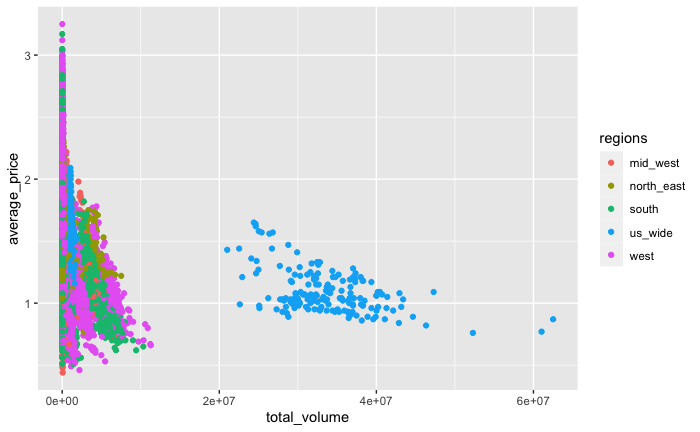

```r
clean_avocados %>%
  ggplot()+
  aes(x = total_volume, y = average_price, colour = regions)+
  geom_point()
```

```r
NA
```

It does appear that the US wide numbers are affecting the distribution so I will filter those out

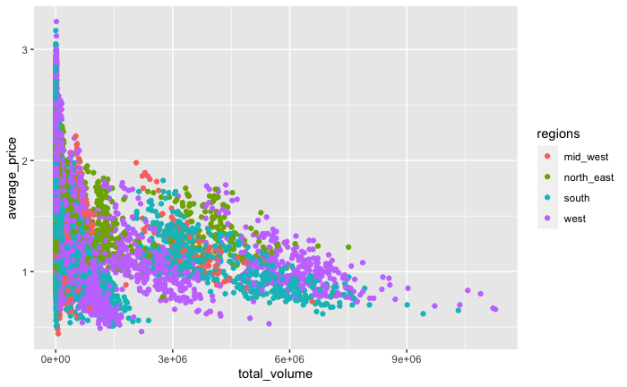

```r
clean_avocados %>%
  filter(regions != "us_wide") %>%
  ggplot()+
  aes(x = total_volume, y = average_price, colour = regions)+
  geom_point()
```

```r
NA
```

That provides a much better distribution

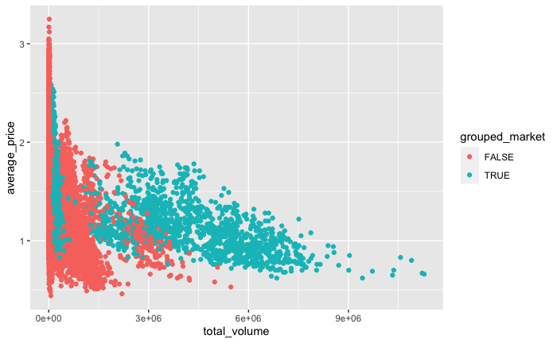

```r
clean_avocados %>%
  filter(regions != "us_wide") %>%
  ggplot()+
  aes(x = total_volume, y = average_price, colour = grouped_market)+
  geom_point()
```

```r
NA
```

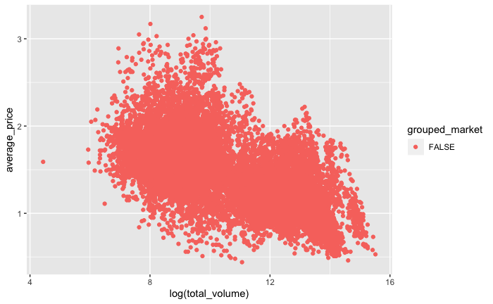

```r
clean_avocados %>%
  filter(grouped_market == F) %>%
  ggplot()+
  aes(x = log(total_volume), y = average_price, colour = grouped_market)+
  geom_point()
```

```r
NA
```

The shape fo the distribution is pretty much the same so I will keep them in

A log transformation might be a good option for understanding total volume

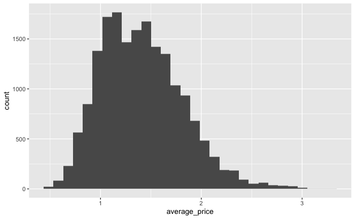

```r
clean_avocados %>%
  ggplot(aes(x =average_price))+
  geom_histogram()
```

Average price seems fairly even distibuted so i won’t need to worry too much about transforig it

```r
clean_avocados <- clean_avocados %>%
  filter(regions != "us_wide")
```

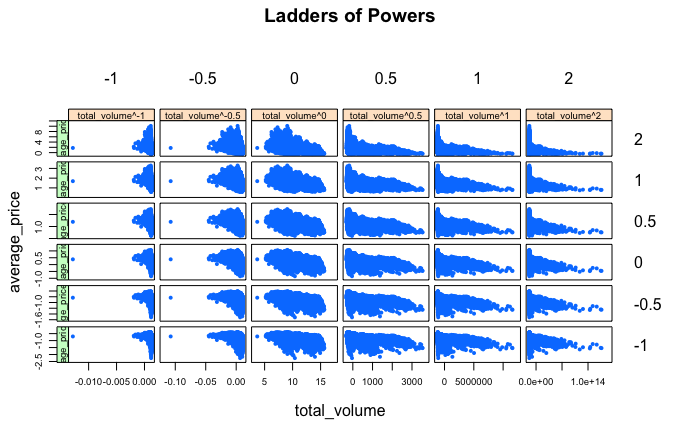

```r
library(HH)
ladder(average_price ~ total_volume, data = clean_avocados)
```

transformation doesn’t offer a huge amount when looking at average price but it does for total volume

```r
test <- clean_avocados %>%
  mutate(test_column = if_else( x4046 > 0, log(x4046),0))

summary(test)
```

```
 quarter    year      average_price    total_volume          x4046             x4225             x4770            total_bags        small_bags
 1:5406   2015:5511   Min.   :0.440   Min.   :      85   Min.   :      0   Min.   :      0   Min.   :     0.0   Min.   :      0   Min.   :      0
 2:4132   2016:5512   1st Qu.:1.100   1st Qu.:   10571   1st Qu.:    820   1st Qu.:   2910   1st Qu.:     0.0   1st Qu.:   4905   1st Qu.:   2700
 3:4134   2017:5616   Median :1.370   Median :  100154   Median :   7824   Median :  26702   Median :   164.2   Median :  37551   Median :  24531
 4:4239   2018:1272   Mean   :1.408   Mean   :  539259   Mean   : 183807   Mean   : 188223   Mean   : 14551.2   Mean   : 152676   Mean   : 116203
                      3rd Qu.:1.670   3rd Qu.:  400177   3rd Qu.: 101489   3rd Qu.: 131755   3rd Qu.:  5736.7   3rd Qu.: 103692   3rd Qu.:  79283
                      Max.   :3.250   Max.   :11274749   Max.   :5160897   Max.   :5402444   Max.   :804558.2   Max.   :4145407   Max.   :3403581
   large_bags       x_large_bags                type            regions     grouped_market   test_column
 Min.   :      0   Min.   :     0.0   conventional:8957   mid_west  :2704   Mode :logical   Min.   : 0.000
 1st Qu.:    113   1st Qu.:     0.0   organic     :8954   north_east:4056   FALSE:15207     1st Qu.: 6.709
 Median :   2459   Median :     0.0                       south     :6422   TRUE :2704      Median : 8.965
 Mean   :  34506   Mean   :  1967.2                       us_wide   :   0                   Mean   : 8.888
 3rd Qu.:  19422   3rd Qu.:   106.8                       west      :4729                   3rd Qu.:11.528
 Max.   :2838239   Max.   :131300.8                                                         Max.   :15.457
```

```r
n_data <- nrow(clean_avocados)
test_index <- sample(1:n_data, size = n_data*0.1)

test  <- slice(clean_avocados, test_index)
train <- slice(clean_avocados, -test_index)
```

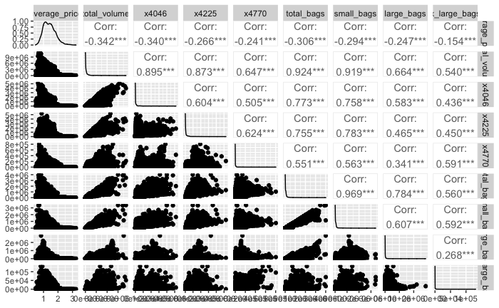

```r
numeric_avocados <- train %>%
  dplyr::select(where(is.numeric))

non_numeric_avocados <- train %>%
  dplyr::select(average_price, !is.numeric)

ggpairs(numeric_avocados)
```

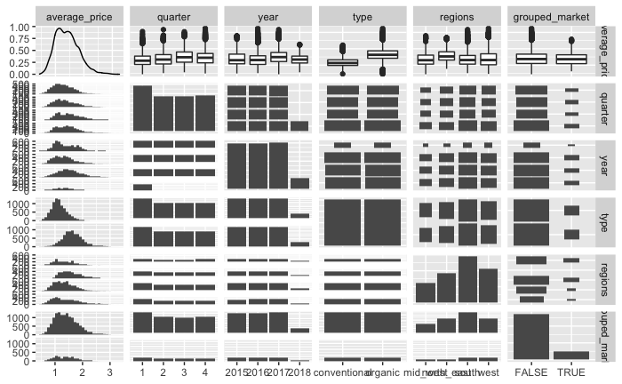

```r
ggpairs(non_numeric_avocados)
```

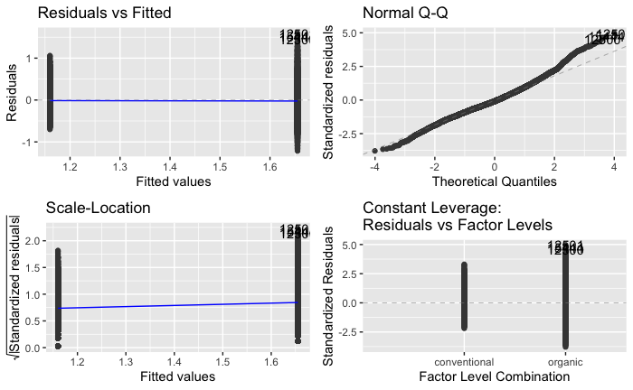

```r
mod1a <- lm(average_price ~ type, data = train)

autoplot(mod1a)
```

```r
summary(mod1a)
```

```
Call:
lm(formula = average_price ~ type, data = train)

Residuals:
     Min       1Q   Median       3Q      Max
-1.21506 -0.20506 -0.02977  0.19023  1.59494

Coefficients:
            Estimate Std. Error t value Pr(>|t|)
(Intercept) 1.159774   0.003576  324.36   <2e-16 ***
typeorganic 0.495284   0.005056   97.97   <2e-16 ***
---
Signif. codes:  0 ‘***’ 0.001 ‘**’ 0.01 ‘*’ 0.05 ‘.’ 0.1 ‘ ’ 1

Residual standard error: 0.3209 on 16118 degrees of freedom
Multiple R-squared:  0.3732,    Adjusted R-squared:  0.3732
F-statistic:  9597 on 1 and 16118 DF,  p-value: < 2.2e-16
```

The fit looks good and the r^2 is 0.37

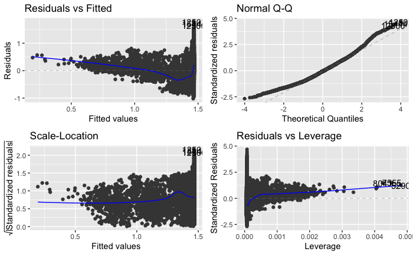

```r
mod1b <- lm(average_price ~ total_volume, data = train)

autoplot(mod1b)
```

```r
summary(mod1b)
```

```
Call:
lm(formula = average_price ~ total_volume, data = train)

Residuals:
     Min       1Q   Median       3Q      Max
-1.02137 -0.28478 -0.02402  0.23847  1.78325

Coefficients:
               Estimate Std. Error t value Pr(>|t|)
(Intercept)   1.469e+00  3.279e-03  447.92   <2e-16 ***
total_volume -1.136e-07  2.457e-09  -46.23   <2e-16 ***
---
Signif. codes:  0 ‘***’ 0.001 ‘**’ 0.01 ‘*’ 0.05 ‘.’ 0.1 ‘ ’ 1

Residual standard error: 0.3809 on 16118 degrees of freedom
Multiple R-squared:  0.1171,    Adjusted R-squared:  0.117
F-statistic:  2137 on 1 and 16118 DF,  p-value: < 2.2e-16
```

There is quite a lot spread in that data lets try a transformation

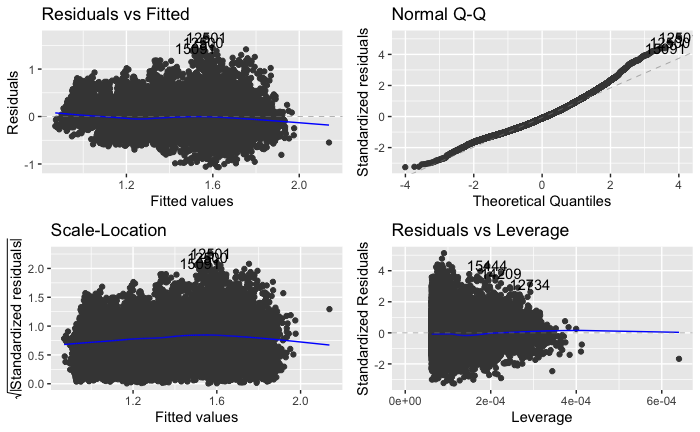

```r
mod1b2 <- lm(average_price ~ log(total_volume), data = train)

autoplot(mod1b2)
```

```r
summary(mod1b2)
```

```
Call:
lm(formula = average_price ~ log(total_volume), data = train)

Residuals:
     Min       1Q   Median       3Q      Max
-1.06718 -0.23038 -0.03414  0.18985  1.68007

Coefficients:
                   Estimate Std. Error t value Pr(>|t|)
(Intercept)        2.614517   0.013262  197.14   <2e-16 ***
log(total_volume) -0.107432   0.001158  -92.78   <2e-16 ***
---
Signif. codes:  0 ‘***’ 0.001 ‘**’ 0.01 ‘*’ 0.05 ‘.’ 0.1 ‘ ’ 1

Residual standard error: 0.3273 on 16118 degrees of freedom
Multiple R-squared:  0.3482,    Adjusted R-squared:  0.3481
F-statistic:  8609 on 1 and 16118 DF,  p-value: < 2.2e-16
```

The fit is much better is but the r^2 stil not as good as the first model.

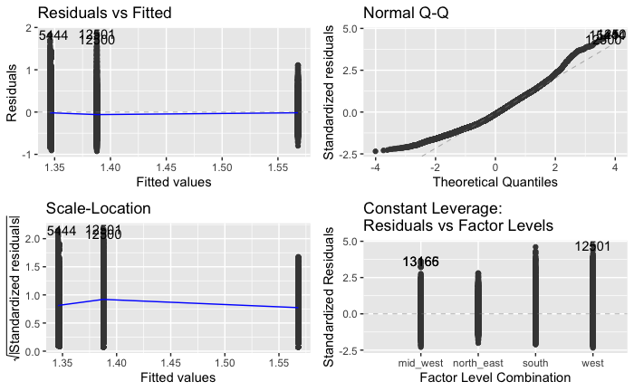

```r
mod1c <- lm(average_price ~ regions, data = train)

autoplot(mod1c)
```

```r
summary(mod1c)
```

```
Call:
lm(formula = average_price ~ regions, data = train)

Residuals:
     Min       1Q   Median       3Q      Max
-0.92782 -0.30588 -0.04719  0.25412  1.86218

Coefficients:
                   Estimate Std. Error t value Pr(>|t|)
(Intercept)        1.347188   0.008004 168.317  < 2e-16 ***
regionsnorth_east  0.220751   0.010337  21.356  < 2e-16 ***
regionssouth      -0.001310   0.009548  -0.137    0.891
regionswest        0.040637   0.010047   4.045 5.27e-05 ***
---
Signif. codes:  0 ‘***’ 0.001 ‘**’ 0.01 ‘*’ 0.05 ‘.’ 0.1 ‘ ’ 1

Residual standard error: 0.3956 on 16116 degrees of freedom
Multiple R-squared:  0.0478,    Adjusted R-squared:  0.04763
F-statistic: 269.7 on 3 and 16116 DF,  p-value: < 2.2e-16
```

type provides a r^2 values so I will go forward with that model

```r
residual_avocado <- train %>%
  add_residuals(mod1a) %>%
  dplyr::select(-c(average_price, type))

res_data_numeric <- residual_avocado %>%
  dplyr::select(is.numeric)

res_data_nonnumeric <- residual_avocado %>%
  dplyr::select( resid, !is.numeric)
```

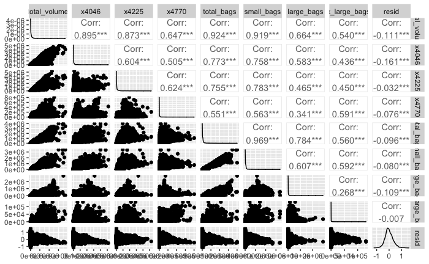

```r
ggpairs(res_data_numeric)
```

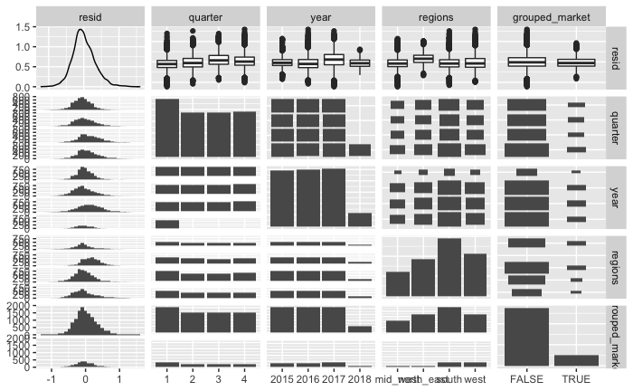

```r
ggpairs(res_data_nonnumeric)
```

Regions, year and total volume look the most promising

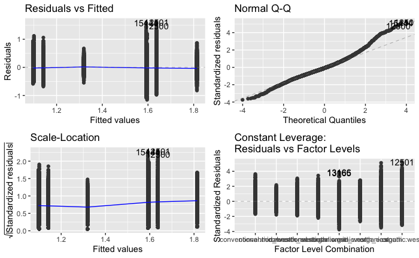

```r
mod2a <- lm(average_price ~ type + regions, data = train)

autoplot(mod2a)
```

```r
summary(mod2a)
```

```
Call:
lm(formula = average_price ~ type + regions, data = train)

Residuals:
     Min       1Q   Median       3Q      Max
-1.15601 -0.19601 -0.02601  0.16799  1.61286

Coefficients:
                   Estimate Std. Error t value Pr(>|t|)
(Intercept)        1.100998   0.006695 164.440  < 2e-16 ***
typeorganic        0.495014   0.004861 101.827  < 2e-16 ***
regionsnorth_east  0.218216   0.008063  27.062  < 2e-16 ***
regionssouth      -0.003998   0.007448  -0.537    0.591
regionswest        0.041128   0.007838   5.247 1.56e-07 ***
---
Signif. codes:  0 ‘***’ 0.001 ‘**’ 0.01 ‘*’ 0.05 ‘.’ 0.1 ‘ ’ 1

Residual standard error: 0.3086 on 16115 degrees of freedom
Multiple R-squared:  0.4206,    Adjusted R-squared:  0.4205
F-statistic:  2925 on 4 and 16115 DF,  p-value: < 2.2e-16
```

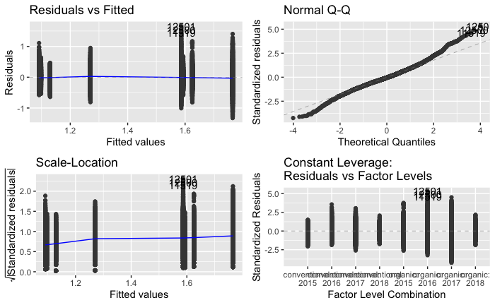

```r
mod2b <- lm(average_price ~ type + year, data = train)

autoplot(mod2b)
```

```r
summary(mod2b)
```

```
Call:
lm(formula = average_price ~ type + year, data = train)

Residuals:
     Min       1Q   Median       3Q      Max
-1.32563 -0.18981 -0.01563  0.18488  1.66332

Coefficients:
             Estimate Std. Error t value Pr(>|t|)
(Intercept)  1.129810   0.005061 223.245  < 2e-16 ***
typeorganic  0.495309   0.004911 100.854  < 2e-16 ***
year2016    -0.038439   0.006263  -6.137 8.59e-10 ***
year2017     0.140514   0.006236  22.533  < 2e-16 ***
year2018    -0.031822   0.010200  -3.120  0.00181 **
---
Signif. codes:  0 ‘***’ 0.001 ‘**’ 0.01 ‘*’ 0.05 ‘.’ 0.1 ‘ ’ 1

Residual standard error: 0.3118 on 16115 degrees of freedom
Multiple R-squared:  0.4087,    Adjusted R-squared:  0.4085
F-statistic:  2784 on 4 and 16115 DF,  p-value: < 2.2e-16
```

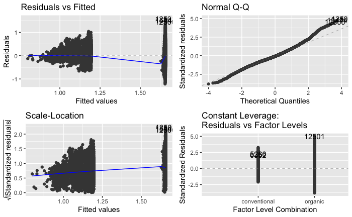

```r
mod2c <- lm(average_price ~ type + total_volume, data = train)

autoplot(mod2c)
```

```r
summary(mod2c)
```

```
Call:
lm(formula = average_price ~ type + total_volume, data = train)

Residuals:
     Min       1Q   Median       3Q      Max
-1.21387 -0.20384 -0.02605  0.18721  1.59445

Coefficients:
               Estimate Std. Error t value Pr(>|t|)
(Intercept)   1.197e+00  4.264e-03  280.63   <2e-16 ***
typeorganic   4.594e-01  5.518e-03   83.25   <2e-16 ***
total_volume -3.533e-08  2.260e-09  -15.63   <2e-16 ***
---
Signif. codes:  0 ‘***’ 0.001 ‘**’ 0.01 ‘*’ 0.05 ‘.’ 0.1 ‘ ’ 1

Residual standard error: 0.3185 on 16117 degrees of freedom
Multiple R-squared:  0.3826,    Adjusted R-squared:  0.3825
F-statistic:  4993 on 2 and 16117 DF,  p-value: < 2.2e-16
```

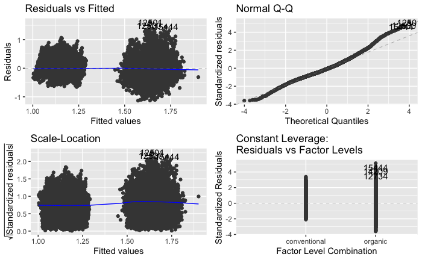

```r
mod2c2 <- lm(average_price ~ type + log(total_volume), data = train)

autoplot(mod2c2)
```

```r
summary(mod2c2)
```

```
Call:
lm(formula = average_price ~ type + log(total_volume), data = train)

Residuals:
     Min       1Q   Median       3Q      Max
-1.13300 -0.20697 -0.02634  0.17975  1.61046

Coefficients:
                   Estimate Std. Error t value Pr(>|t|)
(Intercept)        1.806312   0.025661   70.39   <2e-16 ***
typeorganic        0.314510   0.008666   36.30   <2e-16 ***
log(total_volume) -0.049498   0.001946  -25.43   <2e-16 ***
---
Signif. codes:  0 ‘***’ 0.001 ‘**’ 0.01 ‘*’ 0.05 ‘.’ 0.1 ‘ ’ 1

Residual standard error: 0.3147 on 16117 degrees of freedom
Multiple R-squared:  0.3974,    Adjusted R-squared:  0.3973
F-statistic:  5314 on 2 and 16117 DF,  p-value: < 2.2e-16
```

mod2a <- lm(average_price ~ type + regions, data = train) is the best

```r
anova(mod2a, mod1a)
```

```
Analysis of Variance Table

Model 1: average_price ~ type + regions
Model 2: average_price ~ type
  Res.Df    RSS Df Sum of Sq     F    Pr(>F)
1  16115 1534.7
2  16118 1660.2 -3   -125.51 439.3 < 2.2e-16 ***
---
Signif. codes:  0 ‘***’ 0.001 ‘**’ 0.01 ‘*’ 0.05 ‘.’ 0.1 ‘ ’ 1
```

It is statistically significant so we are good to keep regions in

```r
residual_avocado <- train %>%
  add_residuals(mod2a) %>%
  dplyr::select(-c(average_price, type, regions))

res_data_numeric <- residual_avocado %>%
  dplyr::select(is.numeric)

res_data_nonnumeric <- residual_avocado %>%
  dplyr::select( resid, !is.numeric)
```

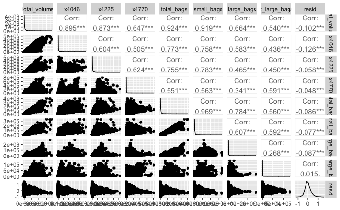

```r
ggpairs(res_data_numeric)
```

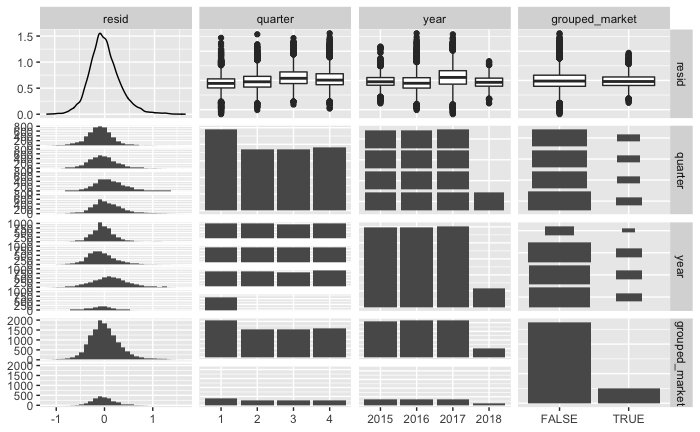

```r
ggpairs(res_data_nonnumeric)
```

```r
mod3a <- lm(average_price ~ type + regions + year, data = train)
summary(mod3a)
```

```
Call:
lm(formula = average_price ~ type + regions + year, data = train)

Residuals:
     Min       1Q   Median       3Q      Max
-1.26652 -0.18066 -0.01716  0.16533  1.68105

Coefficients:
                   Estimate Std. Error t value Pr(>|t|)
(Intercept)        1.071296   0.007380 145.166  < 2e-16 ***
typeorganic        0.495043   0.004711 105.086  < 2e-16 ***
regionsnorth_east  0.218148   0.007814  27.918  < 2e-16 ***
regionssouth      -0.004134   0.007217  -0.573  0.56681
regionswest        0.041397   0.007595   5.451  5.1e-08 ***
year2016          -0.038787   0.006008  -6.456  1.1e-10 ***
year2017           0.140178   0.005981  23.436  < 2e-16 ***
year2018          -0.032645   0.009784  -3.337  0.00085 ***
---
Signif. codes:  0 ‘***’ 0.001 ‘**’ 0.01 ‘*’ 0.05 ‘.’ 0.1 ‘ ’ 1

Residual standard error: 0.299 on 16112 degrees of freedom
Multiple R-squared:  0.456, Adjusted R-squared:  0.4558
F-statistic:  1930 on 7 and 16112 DF,  p-value: < 2.2e-16
```

```r
mod3b <- lm(average_price ~ type + regions + quarter, data = train)
summary(mod3b)
```

```
Call:
lm(formula = average_price ~ type + regions + quarter, data = train)

Residuals:
     Min       1Q   Median       3Q      Max
-1.05447 -0.18938 -0.01983  0.16575  1.60686

Coefficients:
                   Estimate Std. Error t value Pr(>|t|)
(Intercept)        0.999062   0.007365 135.652  < 2e-16 ***
typeorganic        0.495406   0.004686 105.717  < 2e-16 ***
regionsnorth_east  0.218051   0.007773  28.053  < 2e-16 ***
regionssouth      -0.004048   0.007180  -0.564    0.573
regionswest        0.040827   0.007555   5.404 6.62e-08 ***
quarter2           0.072722   0.006475  11.231  < 2e-16 ***
quarter3           0.211507   0.006482  32.631  < 2e-16 ***
quarter4           0.154365   0.006426  24.020  < 2e-16 ***
---
Signif. codes:  0 ‘***’ 0.001 ‘**’ 0.01 ‘*’ 0.05 ‘.’ 0.1 ‘ ’ 1

Residual standard error: 0.2975 on 16112 degrees of freedom
Multiple R-squared:  0.4617,    Adjusted R-squared:  0.4615
F-statistic:  1974 on 7 and 16112 DF,  p-value: < 2.2e-16
```

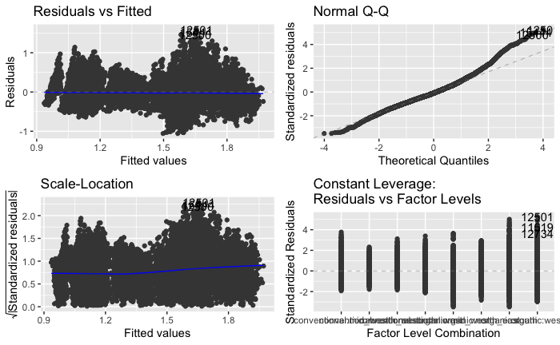

```r
mod3b <- lm(average_price ~ type + regions + log(total_volume), data = train)
autoplot(mod3b)
```

```r
summary(mod3b)
```

```
Call:
lm(formula = average_price ~ type + regions + log(total_volume),
    data = train)

Residuals:
     Min       1Q   Median       3Q      Max
-1.05780 -0.19118 -0.02923  0.16449  1.59484

Coefficients:
                   Estimate Std. Error t value Pr(>|t|)
(Intercept)        1.733899   0.026024  66.627   <2e-16 ***
typeorganic        0.313744   0.008646  36.286   <2e-16 ***
regionsnorth_east  0.218564   0.007910  27.631   <2e-16 ***
regionssouth       0.003928   0.007313   0.537    0.591
regionswest        0.090579   0.007936  11.413   <2e-16 ***
log(total_volume) -0.049681   0.001977 -25.134   <2e-16 ***
---
Signif. codes:  0 ‘***’ 0.001 ‘**’ 0.01 ‘*’ 0.05 ‘.’ 0.1 ‘ ’ 1

Residual standard error: 0.3027 on 16114 degrees of freedom
Multiple R-squared:  0.4425,    Adjusted R-squared:  0.4423
F-statistic:  2558 on 5 and 16114 DF,  p-value: < 2.2e-16
```

```r
anova(mod3b, mod2a)
```

```
Analysis of Variance Table

Model 1: average_price ~ type + regions + log(total_volume)
Model 2: average_price ~ type + regions
  Res.Df    RSS Df Sum of Sq     F    Pr(>F)
1  16114 1476.8
2  16115 1534.7 -1   -57.895 631.7 < 2.2e-16 ***
---
Signif. codes:  0 ‘***’ 0.001 ‘**’ 0.01 ‘*’ 0.05 ‘.’ 0.1 ‘ ’ 1
```

```r
residual_avocado <- train %>%
  add_residuals(mod3b) %>%
  dplyr::select(-c(average_price, type, regions, quarter))

res_data_numeric <- residual_avocado %>%
  dplyr::select(is.numeric)

res_data_nonnumeric <- residual_avocado %>%
  dplyr::select( resid, !is.numeric)
```

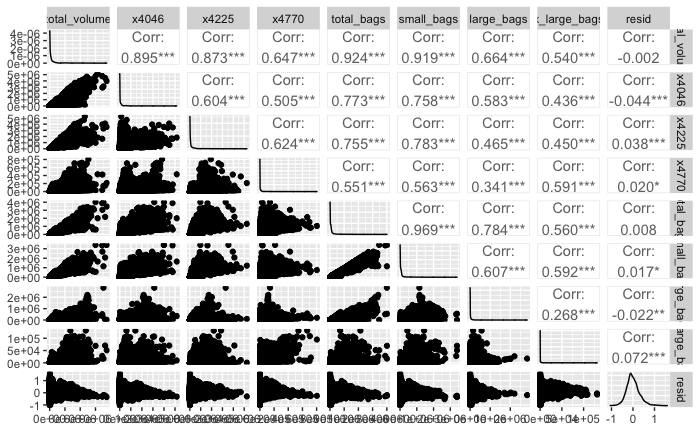

```r
ggpairs(res_data_numeric)
```

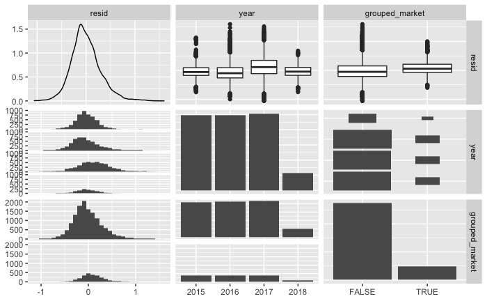

```r
ggpairs(res_data_nonnumeric)
```

```r
mod4a <- lm(average_price ~ type + regions + quarter + year, data = train)
summary(mod4a)
```

```
Call:
lm(formula = average_price ~ type + regions + quarter + year,
    data = train)

Residuals:
     Min       1Q   Median       3Q      Max
-1.14815 -0.17653 -0.01057  0.16647  1.63493

Coefficients:
                   Estimate Std. Error t value Pr(>|t|)
(Intercept)        0.953669   0.008181 116.574  < 2e-16 ***
typeorganic        0.495457   0.004535 109.246  < 2e-16 ***
regionsnorth_east  0.217658   0.007523  28.934  < 2e-16 ***
regionssouth      -0.004434   0.006948  -0.638    0.523
regionswest        0.041016   0.007312   5.610 2.06e-08 ***
quarter2           0.085002   0.006671  12.742  < 2e-16 ***
quarter3           0.223784   0.006677  33.516  < 2e-16 ***
quarter4           0.164411   0.006627  24.809  < 2e-16 ***
year2016          -0.039485   0.005784  -6.827 8.98e-12 ***
year2017           0.139027   0.005759  24.142  < 2e-16 ***
year2018           0.085097   0.010259   8.295  < 2e-16 ***
---
Signif. codes:  0 ‘***’ 0.001 ‘**’ 0.01 ‘*’ 0.05 ‘.’ 0.1 ‘ ’ 1

Residual standard error: 0.2879 on 16109 degrees of freedom
Multiple R-squared:  0.4959,    Adjusted R-squared:  0.4956
F-statistic:  1585 on 10 and 16109 DF,  p-value: < 2.2e-16
```

```r
mod4b <- lm(average_price ~ type + regions + quarter + log(total_volume), data = train)
summary(mod4b)
```

```
Call:
lm(formula = average_price ~ type + regions + quarter + log(total_volume),
    data = train)

Residuals:
     Min       1Q   Median       3Q      Max
-0.97298 -0.18911 -0.02086  0.16819  1.55043

Coefficients:
                   Estimate Std. Error t value Pr(>|t|)
(Intercept)        1.592461   0.025559  62.305   <2e-16 ***
typeorganic        0.326369   0.008364  39.021   <2e-16 ***
regionsnorth_east  0.218397   0.007636  28.603   <2e-16 ***
regionssouth       0.003361   0.007059   0.476    0.634
regionswest        0.086948   0.007662  11.347   <2e-16 ***
quarter2           0.073499   0.006361  11.555   <2e-16 ***
quarter3           0.207001   0.006370  32.496   <2e-16 ***
quarter4           0.144215   0.006327  22.794   <2e-16 ***
log(total_volume) -0.046325   0.001914 -24.207   <2e-16 ***
---
Signif. codes:  0 ‘***’ 0.001 ‘**’ 0.01 ‘*’ 0.05 ‘.’ 0.1 ‘ ’ 1

Residual standard error: 0.2922 on 16111 degrees of freedom
Multiple R-squared:  0.4806,    Adjusted R-squared:  0.4803
F-statistic:  1863 on 8 and 16111 DF,  p-value: < 2.2e-16
```

```r
anova(mod4a, mod3b)
```

```
Analysis of Variance Table

Model 1: average_price ~ type + regions + quarter + year
Model 2: average_price ~ type + regions + log(total_volume)
  Res.Df    RSS Df Sum of Sq      F    Pr(>F)
1  16109 1335.2
2  16114 1476.8 -5   -141.65 341.79 < 2.2e-16 ***
---
Signif. codes:  0 ‘***’ 0.001 ‘**’ 0.01 ‘*’ 0.05 ‘.’ 0.1 ‘ ’ 1
```

```r
mod5a <- lm(average_price ~ type + regions + quarter + year + log(total_volume), data = train)
summary(mod5a)
```

```
Call:
lm(formula = average_price ~ type + regions + quarter + year +
    log(total_volume), data = train)

Residuals:
     Min       1Q   Median       3Q      Max
-1.05477 -0.17410 -0.01015  0.16509  1.62104

Coefficients:
                   Estimate Std. Error t value Pr(>|t|)
(Intercept)        1.624998   0.024577  66.118  < 2e-16 ***
typeorganic        0.298943   0.008116  36.836  < 2e-16 ***
regionsnorth_east  0.217909   0.007335  29.707  < 2e-16 ***
regionssouth       0.004074   0.006782   0.601    0.548
regionswest        0.094561   0.007367  12.836  < 2e-16 ***
quarter2           0.091712   0.006509  14.090  < 2e-16 ***
quarter3           0.224305   0.006511  34.452  < 2e-16 ***
quarter4           0.158160   0.006466  24.461  < 2e-16 ***
year2016          -0.024225   0.005664  -4.277 1.91e-05 ***
year2017           0.161615   0.005670  28.505  < 2e-16 ***
year2018           0.122357   0.010087  12.131  < 2e-16 ***
log(total_volume) -0.053838   0.001864 -28.879  < 2e-16 ***
---
Signif. codes:  0 ‘***’ 0.001 ‘**’ 0.01 ‘*’ 0.05 ‘.’ 0.1 ‘ ’ 1

Residual standard error: 0.2807 on 16108 degrees of freedom
Multiple R-squared:  0.5207,    Adjusted R-squared:  0.5204
F-statistic:  1591 on 11 and 16108 DF,  p-value: < 2.2e-16
```

We are getting very litle for each addition so we will stick with mod4a and look at interations

mod4a <- lm(average_price ~ type + regions + quarter + year, data = train)

type:regions

```r
mod5a  <- lm(average_price ~ type + regions + quarter + year + type:regions, data = train)

summary(mod5a)
```

```
Call:
lm(formula = average_price ~ type + regions + quarter + year +
    type:regions, data = train)

Residuals:
     Min       1Q   Median       3Q      Max
-1.08588 -0.17138 -0.00998  0.16229  1.56088

Coefficients:
                               Estimate Std. Error t value Pr(>|t|)
(Intercept)                    1.015048   0.009635 105.346  < 2e-16 ***
typeorganic                    0.371320   0.011498  32.295  < 2e-16 ***
regionsnorth_east              0.178828   0.010493  17.042  < 2e-16 ***
regionssouth                  -0.053176   0.009688  -5.489 4.11e-08 ***
regionswest                   -0.093181   0.010175  -9.158  < 2e-16 ***
quarter2                       0.084989   0.006584  12.908  < 2e-16 ***
quarter3                       0.223611   0.006590  33.933  < 2e-16 ***
quarter4                       0.165008   0.006541  25.228  < 2e-16 ***
year2016                      -0.039197   0.005708  -6.867 6.80e-12 ***
year2017                       0.139514   0.005684  24.546  < 2e-16 ***
year2018                       0.085379   0.010125   8.432  < 2e-16 ***
typeorganic:regionsnorth_east  0.078536   0.014849   5.289 1.25e-07 ***
typeorganic:regionssouth       0.098280   0.013715   7.166 8.07e-13 ***
typeorganic:regionswest        0.270121   0.014433  18.715  < 2e-16 ***
---
Signif. codes:  0 ‘***’ 0.001 ‘**’ 0.01 ‘*’ 0.05 ‘.’ 0.1 ‘ ’ 1

Residual standard error: 0.2841 on 16106 degrees of freedom
Multiple R-squared:  0.5091,    Adjusted R-squared:  0.5087
F-statistic:  1285 on 13 and 16106 DF,  p-value: < 2.2e-16
```

type:quarter

```r
mod5b  <- lm(average_price ~ type + regions + quarter + year + type:quarter, data = train)

summary(mod5b)
```

```
Call:
lm(formula = average_price ~ type + regions + quarter + year +
    type:quarter, data = train)

Residuals:
     Min       1Q   Median       3Q      Max
-1.13320 -0.17557 -0.01088  0.16515  1.63768

Coefficients:
                      Estimate Std. Error t value Pr(>|t|)
(Intercept)           0.968849   0.008873 109.197  < 2e-16 ***
typeorganic           0.465271   0.008228  56.546  < 2e-16 ***
regionsnorth_east     0.217575   0.007515  28.953  < 2e-16 ***
regionssouth         -0.004457   0.006941  -0.642   0.5208
regionswest           0.040921   0.007304   5.602 2.15e-08 ***
quarter2              0.069512   0.009156   7.592 3.33e-14 ***
quarter3              0.186467   0.009145  20.391  < 2e-16 ***
quarter4              0.151932   0.009085  16.724  < 2e-16 ***
year2016             -0.039540   0.005778  -6.843 8.01e-12 ***
year2017              0.139085   0.005753  24.176  < 2e-16 ***
year2018              0.085061   0.010249   8.300  < 2e-16 ***
typeorganic:quarter2  0.030904   0.012521   2.468   0.0136 *
typeorganic:quarter3  0.074777   0.012533   5.966 2.48e-09 ***
typeorganic:quarter4  0.024886   0.012426   2.003   0.0452 *
---
Signif. codes:  0 ‘***’ 0.001 ‘**’ 0.01 ‘*’ 0.05 ‘.’ 0.1 ‘ ’ 1

Residual standard error: 0.2876 on 16106 degrees of freedom
Multiple R-squared:  0.4971,    Adjusted R-squared:  0.4967
F-statistic:  1224 on 13 and 16106 DF,  p-value: < 2.2e-16
```

type:year

```r
mod5c  <- lm(average_price ~ type + regions + quarter + year + type:year, data = train)

summary(mod5c)
```

```
Call:
lm(formula = average_price ~ type + regions + quarter + year +
    type:year, data = train)

Residuals:
     Min       1Q   Median       3Q      Max
-1.12006 -0.17546 -0.00978  0.16172  1.65001

Coefficients:
                      Estimate Std. Error t value Pr(>|t|)
(Intercept)           0.902977   0.008783 102.805  < 2e-16 ***
typeorganic           0.598260   0.008130  73.583  < 2e-16 ***
regionsnorth_east     0.217047   0.007469  29.061  < 2e-16 ***
regionssouth         -0.004840   0.006898  -0.702 0.482898
regionswest           0.040432   0.007259   5.570 2.59e-08 ***
quarter2              0.085091   0.006623  12.847  < 2e-16 ***
quarter3              0.223751   0.006629  33.753  < 2e-16 ***
quarter4              0.164592   0.006580  25.016  < 2e-16 ***
year2016              0.026821   0.008120   3.303 0.000958 ***
year2017              0.218655   0.008075  27.077  < 2e-16 ***
year2018              0.166355   0.013822  12.036  < 2e-16 ***
typeorganic:year2016 -0.133092   0.011484 -11.589  < 2e-16 ***
typeorganic:year2017 -0.159833   0.011434 -13.978  < 2e-16 ***
typeorganic:year2018 -0.163059   0.018702  -8.719  < 2e-16 ***
---
Signif. codes:  0 ‘***’ 0.001 ‘**’ 0.01 ‘*’ 0.05 ‘.’ 0.1 ‘ ’ 1

Residual standard error: 0.2858 on 16106 degrees of freedom
Multiple R-squared:  0.5032,    Adjusted R-squared:  0.5028
F-statistic:  1255 on 13 and 16106 DF,  p-value: < 2.2e-16
```

reagions:quarter

```r
mod5d  <- lm(average_price ~ type + regions + quarter + year + regions:quarter, data = train)

summary(mod5d)
```

```
Call:
lm(formula = average_price ~ type + regions + quarter + year +
    regions:quarter, data = train)

Residuals:
    Min      1Q  Median      3Q     Max
-1.1477 -0.1718 -0.0082  0.1635  1.5821

Coefficients:
                            Estimate Std. Error t value Pr(>|t|)
(Intercept)                 0.953227   0.011357  83.934  < 2e-16 ***
typeorganic                 0.495598   0.004477 110.697  < 2e-16 ***
regionsnorth_east           0.253233   0.013491  18.771  < 2e-16 ***
regionssouth                0.016475   0.012439   1.324  0.18536
regionswest                -0.015548   0.013078  -1.189  0.23449
quarter2                    0.068728   0.016035   4.286 1.83e-05 ***
quarter3                    0.234160   0.016027  14.610  < 2e-16 ***
quarter4                    0.171987   0.015941  10.789  < 2e-16 ***
year2016                   -0.039324   0.005709  -6.888 5.89e-12 ***
year2017                    0.138831   0.005685  24.420  < 2e-16 ***
year2018                    0.084464   0.010128   8.340  < 2e-16 ***
regionsnorth_east:quarter2  0.066366   0.020504   3.237  0.00121 **
regionssouth:quarter2      -0.005301   0.018947  -0.280  0.77964
regionswest:quarter2        0.009049   0.019959   0.453  0.65029
regionsnorth_east:quarter3 -0.108528   0.020556  -5.280 1.31e-07 ***
regionssouth:quarter3      -0.058694   0.018958  -3.096  0.00197 **
regionswest:quarter3        0.130997   0.019906   6.581 4.82e-11 ***
regionsnorth_east:quarter4 -0.110247   0.020378  -5.410 6.38e-08 ***
regionssouth:quarter4      -0.026357   0.018822  -1.400  0.16144
regionswest:quarter4        0.101980   0.019821   5.145 2.71e-07 ***
---
Signif. codes:  0 ‘***’ 0.001 ‘**’ 0.01 ‘*’ 0.05 ‘.’ 0.1 ‘ ’ 1

Residual standard error: 0.2842 on 16100 degrees of freedom
Multiple R-squared:  0.5091,    Adjusted R-squared:  0.5085
F-statistic: 878.7 on 19 and 16100 DF,  p-value: < 2.2e-16
```

regions:year

```r
mod5e  <- lm(average_price ~ type + regions + quarter + year + regions:year, data = train)

summary(mod5e)
```

```
Call:
lm(formula = average_price ~ type + regions + quarter + year +
    regions:year, data = train)

Residuals:
     Min       1Q   Median       3Q      Max
-1.12997 -0.17694 -0.01064  0.16731  1.62943

Coefficients:
                            Estimate Std. Error t value Pr(>|t|)
(Intercept)                 0.971646   0.011376  85.409  < 2e-16 ***
typeorganic                 0.495658   0.004513 109.838  < 2e-16 ***
regionsnorth_east           0.186617   0.013493  13.830  < 2e-16 ***
regionssouth                0.001017   0.012444   0.082 0.934878
regionswest                -0.008439   0.013102  -0.644 0.519497
quarter2                    0.085014   0.006638  12.808  < 2e-16 ***
quarter3                    0.223824   0.006644  33.690  < 2e-16 ***
quarter4                    0.164274   0.006594  24.912  < 2e-16 ***
year2016                   -0.061452   0.014758  -4.164 3.15e-05 ***
year2017                    0.102661   0.014691   6.988 2.89e-12 ***
year2018                    0.086276   0.024586   3.509 0.000451 ***
regionsnorth_east:year2016  0.093639   0.019083   4.907 9.34e-07 ***
regionssouth:year2016      -0.041319   0.017619  -2.345 0.019031 *
regionswest:year2016        0.058888   0.018525   3.179 0.001482 **
regionsnorth_east:year2017  0.025339   0.018992   1.334 0.182166
regionssouth:year2017       0.026446   0.017530   1.509 0.131415
regionswest:year2017        0.080556   0.018463   4.363 1.29e-05 ***
regionsnorth_east:year2018 -0.078932   0.031170  -2.532 0.011341 *
regionssouth:year2018      -0.014725   0.028843  -0.511 0.609701
regionswest:year2018        0.085507   0.030414   2.811 0.004938 **
---
Signif. codes:  0 ‘***’ 0.001 ‘**’ 0.01 ‘*’ 0.05 ‘.’ 0.1 ‘ ’ 1

Residual standard error: 0.2865 on 16100 degrees of freedom
Multiple R-squared:  0.5013,    Adjusted R-squared:  0.5007
F-statistic: 851.6 on 19 and 16100 DF,  p-value: < 2.2e-16
```

quarter:year

```r
mod5f  <- lm(average_price ~ type + regions + quarter + year + quarter:year, data = train)

summary(mod5e)
```

[output not shown]

```
Call:
lm(formula = average_price ~ type + regions + quarter + year +
    regions:year, data = train)

Residuals:
     Min       1Q   Median       3Q      Max
-1.12997 -0.17694 -0.01064  0.16731  1.62943

Coefficients:
                            Estimate Std. Error t value Pr(>|t|)
(Intercept)                 0.971646   0.011376  85.409  < 2e-16 ***
typeorganic                 0.495658   0.004513 109.838  < 2e-16 ***
regionsnorth_east           0.186617   0.013493  13.830  < 2e-16 ***
regionssouth                0.001017   0.012444   0.082 0.934878
regionswest                -0.008439   0.013102  -0.644 0.519497
quarter2                    0.085014   0.006638  12.808  < 2e-16 ***
quarter3                    0.223824   0.006644  33.690  < 2e-16 ***
quarter4                    0.164274   0.006594  24.912  < 2e-16 ***
year2016                   -0.061452   0.014758  -4.164 3.15e-05 ***
year2017                    0.102661   0.014691   6.988 2.89e-12 ***
year2018                    0.086276   0.024586   3.509 0.000451 ***
regionsnorth_east:year2016  0.093639   0.019083   4.907 9.34e-07 ***
regionssouth:year2016      -0.041319   0.017619  -2.345 0.019031 *
regionswest:year2016        0.058888   0.018525   3.179 0.001482 **
regionsnorth_east:year2017  0.025339   0.018992   1.334 0.182166
regionssouth:year2017       0.026446   0.017530   1.509 0.131415
regionswest:year2017        0.080556   0.018463   4.363 1.29e-05 ***
regionsnorth_east:year2018 -0.078932   0.031170  -2.532 0.011341 *
regionssouth:year2018      -0.014725   0.028843  -0.511 0.609701
regionswest:year2018        0.085507   0.030414   2.811 0.004938 **
---
Signif. codes:  0 ‘***’ 0.001 ‘**’ 0.01 ‘*’ 0.05 ‘.’ 0.1 ‘ ’ 1

Residual standard error: 0.2865 on 16100 degrees of freedom
Multiple R-squared:  0.5013,    Adjusted R-squared:  0.5007
F-statistic: 851.6 on 19 and 16100 DF,  p-value: < 2.2e-16
```

mod5d <- lm(average_price ~ type + regions + quarter + year + regions:quarter, data = train)

```r
anova(mod4a, mod5d)
```

```
Analysis of Variance Table

Model 1: average_price ~ type + regions + quarter + year
Model 2: average_price ~ type + regions + quarter + year + regions:quarter
  Res.Df    RSS Df Sum of Sq      F    Pr(>F)
1  16109 1335.2
2  16100 1300.4  9    34.813 47.891 < 2.2e-16 ***
---
Signif. codes:  0 ‘***’ 0.001 ‘**’ 0.01 ‘*’ 0.05 ‘.’ 0.1 ‘ ’ 1
```

```r
glance(mod5d)
```

| r.squared | adj.r.squared | sigma | statistic | p.value | df | logLik | AIC | BIC | deviance | df.residual | nobs |
| --- | --- | --- | --- | --- | --- | --- | --- | --- | --- | --- | --- |
| 0.5090748 | 0.5084954 | 0.2841981 | 878.6956 | 0 | 19 | -2582.973 | 5207.947 | 5369.391 | 1300.374 | 16100 | 16120 |

```r
glance(mod4a)
```

| r.squared | adj.r.squared | sigma | statistic | p.value | df | logLik | AIC | BIC | deviance | df.residual | nobs |
| --- | --- | --- | --- | --- | --- | --- | --- | --- | --- | --- | --- |
| 0.4959321 | 0.4956191 | 0.2878967 | 1584.899 | 0 | 10 | -2795.912 | 5615.824 | 5708.078 | 1335.187 | 16109 | 16120 |

mod5d offers a better model

```r
mod6a <- lm(average_price ~ type + regions + quarter + year + log(total_volume) + regions:quarter, data = train)

summary(mod6a)
```

```
Call:
lm(formula = average_price ~ type + regions + quarter + year +
    log(total_volume) + regions:quarter, data = train)

Residuals:
    Min      1Q  Median      3Q     Max
-1.0738 -0.1723 -0.0097  0.1651  1.5718

Coefficients:
                            Estimate Std. Error t value Pr(>|t|)
(Intercept)                 1.612119   0.025491  63.244  < 2e-16 ***
typeorganic                 0.302647   0.008017  37.752  < 2e-16 ***
regionsnorth_east           0.253876   0.013159  19.293  < 2e-16 ***
regionssouth                0.023375   0.012135   1.926  0.05409 .
regionswest                 0.039549   0.012900   3.066  0.00217 **
quarter2                    0.074681   0.015642   4.774 1.82e-06 ***
quarter3                    0.234998   0.015633  15.032  < 2e-16 ***
quarter4                    0.167170   0.015550  10.751  < 2e-16 ***
year2016                   -0.024346   0.005593  -4.353 1.35e-05 ***
year2017                    0.161026   0.005599  28.761  < 2e-16 ***
year2018                    0.121068   0.009961  12.155  < 2e-16 ***
log(total_volume)          -0.052860   0.001842 -28.700  < 2e-16 ***
regionsnorth_east:quarter2  0.064501   0.019999   3.225  0.00126 **
regionssouth:quarter2      -0.003593   0.018481  -0.194  0.84585
regionswest:quarter2        0.010840   0.019468   0.557  0.57767
regionsnorth_east:quarter3 -0.109617   0.020050  -5.467 4.64e-08 ***
regionssouth:quarter3      -0.054731   0.018492  -2.960  0.00308 **
regionswest:quarter3        0.125383   0.019417   6.457 1.10e-10 ***
regionsnorth_east:quarter4 -0.109055   0.019876  -5.487 4.16e-08 ***
regionssouth:quarter4      -0.025718   0.018359  -1.401  0.16127
regionswest:quarter4        0.095049   0.019334   4.916 8.92e-07 ***
---
Signif. codes:  0 ‘***’ 0.001 ‘**’ 0.01 ‘*’ 0.05 ‘.’ 0.1 ‘ ’ 1

Residual standard error: 0.2772 on 16099 degrees of freedom
Multiple R-squared:  0.533, Adjusted R-squared:  0.5324
F-statistic: 918.6 on 20 and 16099 DF,  p-value: < 2.2e-16
```

```r
anova(mod5a, mod6a)
```

```
Analysis of Variance Table

Model 1: average_price ~ type + regions + quarter + year + type:regions
Model 2: average_price ~ type + regions + quarter + year + log(total_volume) +
    regions:quarter
  Res.Df    RSS Df Sum of Sq      F    Pr(>F)
1  16106 1300.3
2  16099 1237.1  7    63.226 117.54 < 2.2e-16 ***
---
Signif. codes:  0 ‘***’ 0.001 ‘**’ 0.01 ‘*’ 0.05 ‘.’ 0.1 ‘ ’ 1
```

A transformation of total volume offers a higher r^2 value so I will keep that in

```r
library(relaimpo)
calc.relimp(mod6a, type = "lmg", rela = TRUE)
```

```
Response variable: average_price
Total response variance: 0.1643292
Analysis based on 16120 observations

20 Regressors:
Some regressors combined in groups:
        Group  regions : regionsnorth_east regionssouth regionswest
        Group  quarter : quarter2 quarter3 quarter4
        Group  year : year2016 year2017 year2018
        Group  regions:quarter : regionsnorth_east:quarter2 regionssouth:quarter2 regionswest:quarter2 regionsnorth_east:quarter3 regionssouth:quarter3 regionswest:quarter3 regionsnorth_east:quarter4 regionssouth:quarter4 regionswest:quarter4

 Relative importance of 6 (groups of) regressors assessed:
 regions quarter year regions:quarter type log(total_volume)

Proportion of variance explained by model: 53.3%
Metrics are normalized to sum to 100% (rela=TRUE).

Relative importance metrics:

                         lmg
regions           0.08878378
quarter           0.07361254
year              0.07259015
regions:quarter   0.02315470
type              0.39143724
log(total_volume) 0.35042159

Average coefficients for different model sizes:

                                 1group      2groups       3groups      4groups      5groups      6groups
type                        0.495283561  0.450127193  0.4038234435  0.382614429  0.374842195  0.302646669
regionsnorth_east           0.220750881  0.219736428  0.2236945731  0.233248071  0.244649114  0.253875997
regionssouth               -0.001310114  0.001796042  0.0055472702  0.011635763  0.018447402  0.023374773
regionswest                 0.040636769  0.068100132  0.0709633658  0.062566628  0.052267718  0.039548626
quarter2                    0.073928997  0.076976138  0.0778907920  0.075450588  0.074390904  0.074680941
quarter3                    0.209872967  0.211170272  0.2152444793  0.220106988  0.227547445  0.234998382
quarter4                    0.154689516  0.151280633  0.1529606150  0.155550463  0.160594009  0.167169610
year2016                   -0.035340314 -0.029202240 -0.0252145123 -0.026041583 -0.023602123 -0.024345895
year2017                    0.142508603  0.152628911  0.1593766387  0.158155206  0.162107458  0.161026002
year2018                   -0.030219289  0.017047887  0.0585915046  0.092260734  0.122823003  0.121068445
log(total_volume)          -0.107432073 -0.093765222 -0.0799888551 -0.074871837 -0.070126592 -0.052859646
regionsnorth_east:quarter2          NaN          NaN  0.0716232353  0.067462847  0.065212583  0.064500914
regionssouth:quarter2               NaN          NaN -0.0004774826 -0.002336784 -0.003328121 -0.003593061
regionswest:quarter2                NaN          NaN  0.0118405988  0.011410157  0.011066702  0.010839791
regionsnorth_east:quarter3          NaN          NaN -0.1028382792 -0.106752604 -0.108904462 -0.109616955
regionssouth:quarter3               NaN          NaN -0.0560111447 -0.054668342 -0.054271797 -0.054731013
regionswest:quarter3                NaN          NaN  0.1369503651  0.130043943  0.126392065  0.125383201
regionsnorth_east:quarter4          NaN          NaN -0.1051881749 -0.106461215 -0.107754527 -0.109055017
regionssouth:quarter4               NaN          NaN -0.0229470034 -0.024076658 -0.024946032 -0.025718446
regionswest:quarter4                NaN          NaN  0.0999924945  0.097994205  0.096497573  0.095048953
```

Type and total volume are the most important factor in determining the price of avocados

## Predictive model

```r
model <-lm(formula = average_price ~ quarter + year + type + regions +
  total_volume + x4225 + x4225 + x_large_bags + x_large_bags + grouped_market + regions:quarter,
    data = train)
summary(model)
```

```
Call:
lm(formula = average_price ~ quarter + year + type + regions +
    total_volume + x4225 + x4225 + x_large_bags + x_large_bags +
    grouped_market + regions:quarter, data = train)

Residuals:
     Min       1Q   Median       3Q      Max
-1.12143 -0.17001 -0.01078  0.15991  1.58068

Coefficients:
                             Estimate Std. Error t value Pr(>|t|)
(Intercept)                 9.641e-01  1.141e-02  84.512  < 2e-16 ***
quarter2                    6.983e-02  1.583e-02   4.411 1.03e-05 ***
quarter3                    2.328e-01  1.583e-02  14.707  < 2e-16 ***
quarter4                    1.759e-01  1.575e-02  11.167  < 2e-16 ***
year2016                   -3.910e-02  5.666e-03  -6.901 5.35e-12 ***
year2017                    1.398e-01  5.664e-03  24.688  < 2e-16 ***
year2018                    8.959e-02  1.007e-02   8.898  < 2e-16 ***
typeorganic                 4.623e-01  5.153e-03  89.719  < 2e-16 ***
regionsnorth_east           2.568e-01  1.341e-02  19.141  < 2e-16 ***
regionssouth                4.300e-02  1.240e-02   3.468 0.000525 ***
regionswest                 1.877e-02  1.303e-02   1.440 0.149796
total_volume               -8.338e-08  4.359e-09 -19.126  < 2e-16 ***
x4225                       1.129e-07  1.072e-08  10.531  < 2e-16 ***
x_large_bags                2.848e-06  3.297e-07   8.640  < 2e-16 ***
grouped_marketTRUE          3.794e-02  7.937e-03   4.780 1.77e-06 ***
quarter2:regionsnorth_east  6.529e-02  2.024e-02   3.225 0.001262 **
quarter3:regionsnorth_east -1.092e-01  2.030e-02  -5.378 7.64e-08 ***
quarter4:regionsnorth_east -1.131e-01  2.013e-02  -5.622 1.92e-08 ***
quarter2:regionssouth      -8.125e-03  1.871e-02  -0.434 0.664105
quarter3:regionssouth      -6.505e-02  1.872e-02  -3.474 0.000514 ***
quarter4:regionssouth      -3.554e-02  1.859e-02  -1.911 0.055962 .
quarter2:regionswest        1.116e-02  1.971e-02   0.566 0.571181
quarter3:regionswest        1.266e-01  1.965e-02   6.443 1.20e-10 ***
quarter4:regionswest        8.752e-02  1.959e-02   4.468 7.94e-06 ***
---
Signif. codes:  0 ‘***’ 0.001 ‘**’ 0.01 ‘*’ 0.05 ‘.’ 0.1 ‘ ’ 1

Residual standard error: 0.2806 on 16096 degrees of freedom
Multiple R-squared:  0.5216,    Adjusted R-squared:  0.5209
F-statistic: 763.1 on 23 and 16096 DF,  p-value: < 2.2e-16
```

```r
calc.relimp(model, type = "lmg", rela = TRUE)
```

```
Response variable: average_price
Total response variance: 0.1643292
Analysis based on 16120 observations

23 Regressors:
Some regressors combined in groups:
        Group  quarter : quarter2 quarter3 quarter4
        Group  year : year2016 year2017 year2018
        Group  regions : regionsnorth_east regionssouth regionswest
        Group  quarter:regions : quarter2:regionsnorth_east quarter3:regionsnorth_east quarter4:regionsnorth_east quarter2:regionssouth quarter3:regionssouth quarter4:regionssouth quarter2:regionswest quarter3:regionswest quarter4:regionswest

 Relative importance of 9 (groups of) regressors assessed:
 quarter year regions quarter:regions type total_volume x4225 x_large_bags grouped_market

Proportion of variance explained by model: 52.16%
Metrics are normalized to sum to 100% (rela=TRUE).

Relative importance metrics:

                       lmg
quarter         0.07445340
year            0.06671435
regions         0.08982883
quarter:regions 0.02404147
type            0.56603969
total_volume    0.10005041
x4225           0.04986580
x_large_bags    0.01331897
grouped_market  0.01568709

Average coefficients for different model sizes:

                                  1group       2groups       3groups       4groups       5groups       6groups       7groups       8groups       9groups
quarter2                    7.392900e-02  7.552511e-02  7.620549e-02  7.558077e-02  7.400632e-02  7.210506e-02  7.050358e-02  6.969089e-02  6.983498e-02
quarter3                    2.098730e-01  2.109395e-01  2.121083e-01  2.135223e-01  2.155799e-01  2.185503e-01  2.225181e-01  2.274024e-01  2.327765e-01
quarter4                    1.546895e-01  1.517623e-01  1.512378e-01  1.519051e-01  1.537883e-01  1.572235e-01  1.622538e-01  1.685841e-01  1.758572e-01
year2016                   -3.534031e-02 -3.353398e-02 -3.329939e-02 -3.403373e-02 -3.490372e-02 -3.580230e-02 -3.693462e-02 -3.795121e-02 -3.910168e-02
year2017                    1.425086e-01  1.441495e-01  1.443576e-01  1.437347e-01  1.430272e-01  1.421475e-01  1.409681e-01  1.402755e-01  1.398284e-01
year2018                   -3.021929e-02 -7.472921e-03  1.209966e-02  3.105805e-02  5.151390e-02  7.137386e-02  8.521387e-02  9.074532e-02  8.959242e-02
type                        4.952836e-01  4.886394e-01  4.832213e-01  4.788250e-01  4.753743e-01  4.725111e-01  4.695200e-01  4.659899e-01  4.622990e-01
regionsnorth_east           2.207509e-01  2.204157e-01  2.242189e-01  2.294077e-01  2.356153e-01  2.426550e-01  2.492971e-01  2.540284e-01  2.567626e-01
regionssouth               -1.310114e-03 -2.802948e-03 -1.243492e-03  2.303623e-03  7.471052e-03  1.433747e-02  2.281487e-02  3.243917e-02  4.300065e-02
regionswest                 4.063677e-02  5.155791e-02  5.534619e-02  5.370518e-02  4.809761e-02  4.025396e-02  3.189210e-02  2.431949e-02  1.877012e-02
total_volume               -1.136018e-07 -1.147801e-07 -1.139925e-07 -1.112705e-07 -1.068398e-07 -1.010968e-07 -9.469643e-08 -8.851309e-08 -8.337808e-08
x4225                      -2.392669e-07 -1.655357e-07 -9.824319e-08 -4.430693e-08 -9.321085e-09  1.091683e-08  3.311641e-08  6.926011e-08  1.128636e-07
x_large_bags               -7.620874e-06 -4.391891e-06 -1.930811e-06 -3.187361e-07  6.763538e-07  1.405833e-06  2.027340e-06  2.471373e-06  2.848399e-06
grouped_market             -4.439986e-02  3.725400e-02  8.299405e-02  9.813380e-02  9.933046e-02  9.853502e-02  9.205724e-02  7.129206e-02  3.793525e-02
quarter2:regionsnorth_east           NaN           NaN  7.162324e-02  7.093512e-02  6.967014e-02  6.829421e-02  6.710803e-02  6.618363e-02  6.529247e-02
quarter3:regionsnorth_east           NaN           NaN -1.028383e-01 -1.023967e-01 -1.034470e-01 -1.050427e-01 -1.065960e-01 -1.078995e-01 -1.091552e-01
quarter4:regionsnorth_east           NaN           NaN -1.051882e-01 -1.039726e-01 -1.052414e-01 -1.074409e-01 -1.096072e-01 -1.113993e-01 -1.131404e-01
quarter2:regionssouth                NaN           NaN -4.774826e-04  5.815000e-04 -4.320882e-04 -2.341623e-03 -4.391133e-03 -6.266108e-03 -8.124972e-03
quarter3:regionssouth                NaN           NaN -5.601114e-02 -5.380599e-02 -5.443175e-02 -5.655351e-02 -5.927049e-02 -6.211206e-02 -6.504671e-02
quarter4:regionssouth                NaN           NaN -2.294700e-02 -2.147616e-02 -2.263300e-02 -2.526173e-02 -2.851370e-02 -3.192842e-02 -3.554122e-02
quarter2:regionswest                 NaN           NaN  1.184060e-02  1.057894e-02  9.636338e-03  9.245950e-03  9.473742e-03  1.020888e-02  1.116050e-02
quarter3:regionswest                 NaN           NaN  1.369504e-01  1.342455e-01  1.317261e-01  1.296966e-01  1.282296e-01  1.272486e-01  1.266325e-01
quarter4:regionswest                 NaN           NaN  9.999249e-02  1.007678e-01  9.840038e-02  9.505358e-02  9.197873e-02  8.958569e-02  8.752211e-02
```

This model still puts type and total volume as the most important. We know from my model that a tranasfomration of total volume works better.

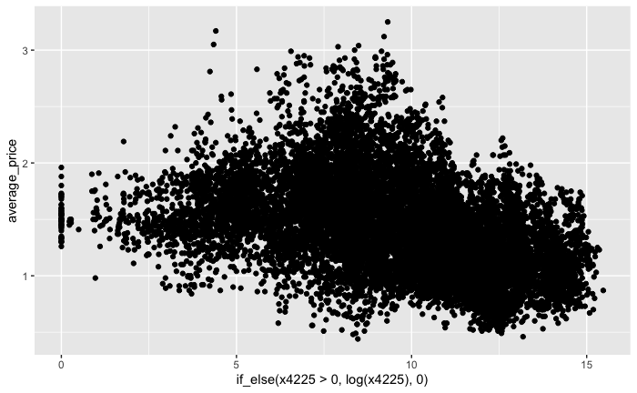

```r
train %>%
  ggplot()+
  aes(x =if_else(x4225 > 0, log(x4225), 0), y= average_price)+
  geom_point()
```

```r
glmulti_all_trans <- lm(average_price~ quarter+year+type+regions+log(total_volume)+if_else(x4225 > 0, log(x4225), 0)+if_else(x_large_bags > 0, log(x_large_bags), 0) +grouped_market + regions:quarter, data = train)

summary(glmulti_all_trans)
```

```
Call:
lm(formula = average_price ~ quarter + year + type + regions +
    log(total_volume) + if_else(x4225 > 0, log(x4225), 0) + if_else(x_large_bags >
    0, log(x_large_bags), 0) + grouped_market + regions:quarter,
    data = train)

Residuals:
     Min       1Q   Median       3Q      Max
-1.06720 -0.16073 -0.01478  0.14875  1.52947

Coefficients:
                                                  Estimate Std. Error t value Pr(>|t|)
(Intercept)                                      2.2327552  0.0314914  70.900  < 2e-16 ***
quarter2                                         0.0741638  0.0145087   5.112 3.23e-07 ***
quarter3                                         0.2402321  0.0145032  16.564  < 2e-16 ***
quarter4                                         0.1740844  0.0144154  12.076  < 2e-16 ***
year2016                                        -0.0068332  0.0052931  -1.291  0.19674
year2017                                         0.1965069  0.0053826  36.508  < 2e-16 ***
year2018                                         0.1738272  0.0095348  18.231  < 2e-16 ***
typeorganic                                      0.1976110  0.0102501  19.279  < 2e-16 ***
regionsnorth_east                                0.3102783  0.0123664  25.090  < 2e-16 ***
regionssouth                                     0.1179523  0.0115009  10.256  < 2e-16 ***
regionswest                                      0.0985457  0.0120508   8.177 3.11e-16 ***
log(total_volume)                               -0.1831266  0.0031078 -58.925  < 2e-16 ***
if_else(x4225 > 0, log(x4225), 0)                0.0788307  0.0017923  43.983  < 2e-16 ***
if_else(x_large_bags > 0, log(x_large_bags), 0)  0.0090257  0.0008646  10.439  < 2e-16 ***
grouped_marketTRUE                               0.1819862  0.0082529  22.051  < 2e-16 ***
quarter2:regionsnorth_east                       0.0586635  0.0185485   3.163  0.00157 **
quarter3:regionsnorth_east                      -0.1291180  0.0186144  -6.936 4.17e-12 ***
quarter4:regionsnorth_east                      -0.1028937  0.0184230  -5.585 2.37e-08 ***
quarter2:regionssouth                           -0.0050916  0.0171340  -0.297  0.76635
quarter3:regionssouth                           -0.0678423  0.0171506  -3.956 7.66e-05 ***
quarter4:regionssouth                           -0.0318130  0.0170181  -1.869  0.06159 .
quarter2:regionswest                             0.0174519  0.0180459   0.967  0.33352
quarter3:regionswest                             0.1082384  0.0180033   6.012 1.87e-09 ***
quarter4:regionswest                             0.0703624  0.0179326   3.924 8.76e-05 ***
---
Signif. codes:  0 ‘***’ 0.001 ‘**’ 0.01 ‘*’ 0.05 ‘.’ 0.1 ‘ ’ 1

Residual standard error: 0.2569 on 16096 degrees of freedom
Multiple R-squared:  0.5989,    Adjusted R-squared:  0.5983
F-statistic:  1045 on 23 and 16096 DF,  p-value: < 2.2e-16
```

```r
gli <- glance(glmulti_all_trans) %>%
  mutate(name = "gli_trans") %>%
  dplyr::select(name, r.squared, adj.r.squared,AIC, BIC)

gli2 <- glance(model) %>%
  mutate(name = "gli_non") %>%
  dplyr::select(name, r.squared, adj.r.squared,AIC, BIC)

my_model <- glance(mod6a) %>%
  mutate(name = "mod6a") %>%
  dplyr::select(name, r.squared, adj.r.squared,AIC, BIC)

bind_rows(gli,gli2,  my_model)
```

| name | r.squared | adj.r.squared | AIC | BIC |
| --- | --- | --- | --- | --- |
| gli_trans | 0.5988580 | 0.5982848 | 1960.087 | 2152.283 |
| gli_non | 0.5216176 | 0.5209340 | 4798.737 | 4990.932 |
| mod6a | 0.5329700 | 0.5323898 | 4405.586 | 4574.718 |

The GLI transfromed moel is better is better

```r
predictions <- predict(model, newdata = test)

mean((predictions - test$average_price)**2)
```

```
[1] 0.07095255
```

```r
predictions <- predict(model, newdata = train)

mean((predictions - train$average_price)**2)
```

```
[1] 0.07860732
```

```r
predictions <- predict(glmulti_all_trans, newdata = test)

mean((predictions - test$average_price)**2)
```

```
[1] 0.0599584
```

```r
predictions <- predict(glmulti_all_trans, newdata = train)

mean((predictions - train$average_price)**2)
```

```
[1] 0.06591526
```

```r
predictions <- predict(mod6a, newdata = test)

mean((predictions - test$average_price)**2)
```

```
[1] 0.06943714
```

```r
predictions <- predict(mod6a, newdata =train )

mean((predictions - train$average_price)**2)
```

```
[1] 0.07674192
```

```r
summary(glmulti_all_trans)
```

```
Call:
lm(formula = average_price ~ quarter + year + type + regions +
    log(total_volume) + if_else(x4225 > 0, log(x4225), 0) + if_else(x_large_bags >
    0, log(x_large_bags), 0) + grouped_market + regions:quarter,
    data = train)

Residuals:
     Min       1Q   Median       3Q      Max
-1.06720 -0.16073 -0.01478  0.14875  1.52947

Coefficients:
                                                  Estimate Std. Error t value Pr(>|t|)
(Intercept)                                      2.2327552  0.0314914  70.900  < 2e-16 ***
quarter2                                         0.0741638  0.0145087   5.112 3.23e-07 ***
quarter3                                         0.2402321  0.0145032  16.564  < 2e-16 ***
quarter4                                         0.1740844  0.0144154  12.076  < 2e-16 ***
year2016                                        -0.0068332  0.0052931  -1.291  0.19674
year2017                                         0.1965069  0.0053826  36.508  < 2e-16 ***
year2018                                         0.1738272  0.0095348  18.231  < 2e-16 ***
typeorganic                                      0.1976110  0.0102501  19.279  < 2e-16 ***
regionsnorth_east                                0.3102783  0.0123664  25.090  < 2e-16 ***
regionssouth                                     0.1179523  0.0115009  10.256  < 2e-16 ***
regionswest                                      0.0985457  0.0120508   8.177 3.11e-16 ***
log(total_volume)                               -0.1831266  0.0031078 -58.925  < 2e-16 ***
if_else(x4225 > 0, log(x4225), 0)                0.0788307  0.0017923  43.983  < 2e-16 ***
if_else(x_large_bags > 0, log(x_large_bags), 0)  0.0090257  0.0008646  10.439  < 2e-16 ***
grouped_marketTRUE                               0.1819862  0.0082529  22.051  < 2e-16 ***
quarter2:regionsnorth_east                       0.0586635  0.0185485   3.163  0.00157 **
quarter3:regionsnorth_east                      -0.1291180  0.0186144  -6.936 4.17e-12 ***
quarter4:regionsnorth_east                      -0.1028937  0.0184230  -5.585 2.37e-08 ***
quarter2:regionssouth                           -0.0050916  0.0171340  -0.297  0.76635
quarter3:regionssouth                           -0.0678423  0.0171506  -3.956 7.66e-05 ***
quarter4:regionssouth                           -0.0318130  0.0170181  -1.869  0.06159 .
quarter2:regionswest                             0.0174519  0.0180459   0.967  0.33352
quarter3:regionswest                             0.1082384  0.0180033   6.012 1.87e-09 ***
quarter4:regionswest                             0.0703624  0.0179326   3.924 8.76e-05 ***
---
Signif. codes:  0 ‘***’ 0.001 ‘**’ 0.01 ‘*’ 0.05 ‘.’ 0.1 ‘ ’ 1

Residual standard error: 0.2569 on 16096 degrees of freedom
Multiple R-squared:  0.5989,    Adjusted R-squared:  0.5983
F-statistic:  1045 on 23 and 16096 DF,  p-value: < 2.2e-16
```